# Machine Learning

## Indah Agustien Siradjuddin

# NumPy, Matplotlib, Scikit

Pengenalan library NumPy, Matplotlib, Scikit

## Pendahuluan

Pada komputasi, pengolahan data numerik melalui suatu program sering dibutuhkan. Python secara umum telah menyediakan fasilitas untuk menyimpan data numerik ini dengan menggunakan **list** ataupun **dictionaries**. Akan tetapi jika hanya dibutuhkan tempat penyimpanan data numerik saja, maka akan lebih efektif jika menggunakan library **NumPy**.

Kelebihan yang diberikan NumPy dibandingkan dengan list ataupun dictionaries adalah numPy lebih dekat dengan hardware sehingga waktu komputasi yang dibutuhkan untuk proses komputasi sangatlah cepat, numPy menyediakan berbagai fungsi ataupun method untuk proses komputasi.

## Mode Bantuan

Library NumPy menyedikan juga bantuan interaktif untuk para programmer dalam membuat suatu program. Dengan bantuan ini, programmer dapat mencari syntax-syntax yang dibutuhkan

```python
import numpy as np
```

```python
np.lookfor("max")
```

```python
np.ar*?
```

## Array

Array merupakan tipe data dasar yang sering dibutuhkan dalam proses komputasi. Hampir semua data direpresentasikan dengan array dan operasi dilakukan pada tipe data ini.

### Pembuatan dan Pengaksesan tipe data Array

**Array** dapat dibuat dengan cara manual dan menggunakan fungs secara manuali yang telah disediakan numPy.

Untuk membuat array secara manual dengan menggunakan numPy sama halnya ketika inisialisasi variabel **List**. Berikut syntax pembuatan array 1D

```python
arr1D=np.array([10, 30, 8, 7])
```

```python
print (arr1D)
```

*arrData* tersebut merupakan variable yang bertipe array 1D. *arrData* tersebut memiliki 4 elemen atau anggota. Seperti halnya dengan tipe data list, maka library numPy dengan tipe data Array juga menyediakan index untuk mengakses elemen yang terdapat pada array tersebut. Index dimulai dari nol.

```python
print(arr1D[0])
print(arr1D[1:3])
```

Anggota dari tipe data array ini bersifat **mutable**, yaitu dapat dirubah, seperti contoh berikut

```python
arr1D[3]
```

```python
arr1D[3]=2
print(arr1D)
```

```python
arr1D=np.array([10,100,8,7])
```

Untuk membuat array 2D :

```python
arr2D=np.array([[1,2,3,11],[4,5,6,12],[7,8,9,13]])
```

Untuk mengakses array 2D, dapat dilihat sebagai berikut :

```python
arr2D
```

```python
temp=arr2D[0,2]
print(temp)
print(arr2D[2,0:3])
```

```python
arr2D[:,2]
```

```python
temp=arr2D[1,:]
temp
```

Terdapat beberapa method yang disediakan tipe data array ini, seperti ukuran array (*shape*), jumlah dimensi (*ndim*), panjang dari array (*len*), rata-rata dari seluruh elemen (*mean*), nilai maksimal dari array (*max*), dan lain-lain

```python
len(arr1D)
```

```python
len(arr2D)
```

```python
len(arr2D[0])
```

```python
arr1D.ndim
```

```python
arr2D.ndim
```

```python
a=arr1D.shape
print(a)
```

```python
a=arr2D.shape
print(a)
```

```python
arr1D.max()
```

```python
arr2D.max()
```

```python
a=arr1D.size
b=arr2D.size
```

```python
print (a,b)
```

Selain dengan cara manual, array juga dapat dibuat dengan cara memanggil fungsi yang disediakan oleh library numPy. Terdapat beberapa fungsi yang dapat membangkitkan data numerik, seperti :

- ones, yaitu fungsi untuk membangkitkan suatu matrik dengan ukuran *m* x *n*, dan semua elemen bernilai '1'
- zeros, yaitu fungsi yang membangkitan suatu matrik dengan ukuran *m* x *n*, dan semua elemen bernilai '0'
- eye, yaitu fungsi yang membangkitkan matrik identitas dengan ukuran *n* x *n*
- rand, yaitu fungsi yang membangkitan matrik dengan elemen yang bernilai acak antara 0 s.d 1 dan berukuran *m* x *n*,
- dll

```python
arrOne=np.ones((4,3))
arrZeros=np.zeros((2,4))
arrEye=np.eye(3)
arrRand=np.random.rand(3,1)
arrLinSpace=np.linspace(0,1,10)
```

```python
arrOne
```

```python
arrZeros
```

```python
arrEye
```

```python
arrRand
```

```python
arrLinSpace
```

### Operasi komputasi pada Array

Terdapat beberapa operasi dasar komputasi pada Array :

- Operasi *Elementwise*
- Operasi *Arraywise*
- dll

#### Operasi *Elementwise*

Pada operasi elementwise ini, elemen atau anggota array diperlakukan secara independen, tidak tergantung pada anggota array yang lain. Beberapa contoh operasi *Elementwise* ini antara lain:

##### Operasi Matematika dengan Skalar

Terdapat beberapa operasi Array dengan skalar, antara lain:

- Penjumlahan atau pengurangan
- Perkalian atau pembagian

```python
a=np.array([4,3,2])
b=a+1
c=10-a
d=a*2
print('a=',a)
print('b=',b)
print('c=',c)
print('d=',d)
```

```python
b=a*2
print(b)
```

```python
print(a/2)
```

##### Operasi Matematika antara Array

Operasi *elementwise* juga dapat dilakukan antara beberapa array ataupun matrik, hanya saja setiap elemen pada matrik bersifat independent, hasil operasi tidak dipengaruhi oleh elemen lain dari array. Contoh operasi ini juga dapat dilakukan pada :

- Penjumlahan atau pengurangan
- Perkalian atau pembagian

```python
a=np.array([4,3,2])
b=np.array([2,6,0.5])
c=a+b
d=a-b
e=a*b
f=a/b
print('a=',a,' ; b=',b, '\na+b=',c, '; a-b=', d)
print('a*b=',e, '; a/b=', f)
```

#### Operasi Arraywise

Pada operasi *arraywise* ini, elemen bersifat dependent, operasi tidak dilakukan antara elemen pada suatu array, tapi membutuhkan nilai dari elemen yang lain. Contoh operasi ini adalah operasi perkalian

```python
a=np.array([4,3])
b=np.array([[2,6,0.5],[1,3,4]])
c=a.dot(b)
```

```python
print('a=',a,' ; \nb=',b, '\na*b=',c)
```

```python
a*b
```

Selain *elementwise* ataupun *arraywise*, banyak operasi komputasi atau matematika pada tipe data array ini, seperti sum, transpose, man, mix, dll

## Grafik dan Citra

Grafik maupun citra merupakan hal yang sangat penting dalam proses komputasi. Grafik dapat mempermudah pengguna untuk memahami proses yang berlangsung, begitu juga dengan citra, bahkan citra juga merupakan salah satu input yang harus diproses dalam proses komputasi. Untuk keperluan tersebut, numPy menyediakan fasilitas untuk membuat serta menampilkan grafik maupun citra.

Fungsi-fungsi yang diperlukan untuk menampilkan grafik ataupun citra terdapat library **matplotlib**, oleh karena itu hal pertama yang harus dilakukan adalah import library ini terlebih dahulu

### Grafik

```python
import matplotlib.pyplot as matPlot
from skimage import data, img_as_float
```

Berikut contoh untuk menampilkan grafik dari persamaan : \begin{align} y & = 2x + 3 \end{align}

Tahapan yang harus dilakukan untuk menampilkan grafik sesuai persamaan diatas adalah :

- Membangkitkan data *x* (asumsi, *x* nilai 0 s.d 1, gunakan fungsi *linspace*)
- Hitung nilai *y*, berdasarkan nilai *x* yang ada dan persamaan diatas
- Plot pasangan nilai *x* dan *y*, dengan menggunakan library matplotlib

```python
import numpy as np
```

```python
a=np.array([[1,2,3],[4,5,6]])
print(a)
```

```
[[1 2 3]
 [4 5 6]]
```

```python
b=2*a
print(a)
```

```
[[1 2 3]
 [4 5 6]]
```

```python
x=np.linspace(0,1,20)
y=2*x+3
```

```python
%matplotlib inline
```

```python
matPlot.plot(x,y)
```

```python
matPlot.plot(x,y,'o')
```

### Citra

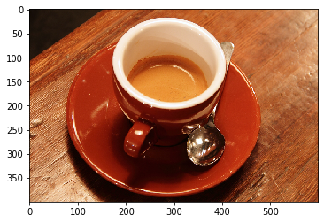

```python
img=data.coffee()
matPlot.imshow(img, cmap='gray')
```

```python
img.shape
```

```
(400, 600, 3)
```

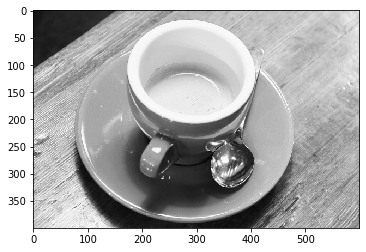

```python
redP=img[:,:,0]
matPlot.imshow(redP, cmap='gray')
```

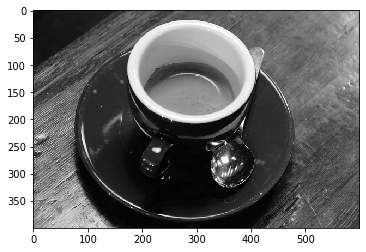

```python
greenP=img[:,:,1]
matPlot.imshow(greenP, cmap='gray')
```

```python
blueP=img[:,:,2]
```

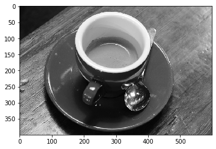

```python
gray=0.299*redP+0.587*greenP+0.114*blueP
matPlot.imshow(gray, cmap='gray')
```

```python
data=img[:,:]
print(data)
```

```python
data1=img[:,:,0]
print(data1)
```

```python
histogram=matPlot.hist(data)
```

```python
print(img)
```

```python
img.size
```

## Data Ujicoba

**Scikit** sudah menyediakan beberapa data untuk ujicoba, seperti iris, diabetes, perumahan, dll. Dataset ini dapat digunakan sebagai ujicoba klasifikasi, estimasi, *clustering*, dll.  
Untuk menggunakan data ini, import scikit terlebih dahulu.

```python
from sklearn import datasets
```

```python
iris=datasets.load_iris()
featIris=iris.data[:,:3]
targetIris=iris.target
```

```python
print(iris.feature_names)
print(featIris)
print(iris.target_names)
print(targetIris)
```

```
['sepal length (cm)', 'sepal width (cm)', 'petal length (cm)', 'petal width (cm)']
[[5.1 3.5 1.4]
 [4.9 3.  1.4]
 [4.7 3.2 1.3]
 [4.6 3.1 1.5]
 [5.  3.6 1.4]
 [5.4 3.9 1.7]
 [4.6 3.4 1.4]
 [5.  3.4 1.5]
 [4.4 2.9 1.4]
 [4.9 3.1 1.5]
 [5.4 3.7 1.5]
 [4.8 3.4 1.6]
 [4.8 3.  1.4]
 [4.3 3.  1.1]
 [5.8 4.  1.2]
 [5.7 4.4 1.5]
 [5.4 3.9 1.3]
 [5.1 3.5 1.4]
 [5.7 3.8 1.7]
 [5.1 3.8 1.5]
 [5.4 3.4 1.7]
 [5.1 3.7 1.5]
 [4.6 3.6 1. ]
 [5.1 3.3 1.7]
 [4.8 3.4 1.9]
 [5.  3.  1.6]
 [5.  3.4 1.6]
 [5.2 3.5 1.5]
 [5.2 3.4 1.4]
 [4.7 3.2 1.6]
 [4.8 3.1 1.6]
 [5.4 3.4 1.5]
 [5.2 4.1 1.5]
 [5.5 4.2 1.4]
 [4.9 3.1 1.5]
 [5.  3.2 1.2]
 [5.5 3.5 1.3]
 [4.9 3.6 1.4]
 [4.4 3.  1.3]
```

[output cut: 102 more lines]

```
 [6.9 3.1 5.1]
 [5.8 2.7 5.1]
 [6.8 3.2 5.9]
 [6.7 3.3 5.7]
 [6.7 3.  5.2]
 [6.3 2.5 5. ]
 [6.5 3.  5.2]
 [6.2 3.4 5.4]
 [5.9 3.  5.1]]
['setosa' 'versicolor' 'virginica']
[0 0 0 0 0 0 0 0 0 0 0 0 0 0 0 0 0 0 0 0 0 0 0 0 0 0 0 0 0 0 0 0 0 0 0 0 0
 0 0 0 0 0 0 0 0 0 0 0 0 0 1 1 1 1 1 1 1 1 1 1 1 1 1 1 1 1 1 1 1 1 1 1 1 1
 1 1 1 1 1 1 1 1 1 1 1 1 1 1 1 1 1 1 1 1 1 1 1 1 1 1 2 2 2 2 2 2 2 2 2 2 2
 2 2 2 2 2 2 2 2 2 2 2 2 2 2 2 2 2 2 2 2 2 2 2 2 2 2 2 2 2 2 2 2 2 2 2 2 2
 2 2]
```

Linear Regression :

1. Definisi dan Studi Kasus

2. Model Linear Regression

3. Training :

   ```
    a. Direct / Matrix Equation
    b. Gradient Descent
   ```

4. Linear Regression dengan Scikit

5. Akurasi

Linear Regression - Definisi

- Model yang paling sederhana di dalam algoritma *Machine Learning*

- Prediksi **nilai real** berdasarkan fitur atau atribut dari data pelatihan (*training*/*learning*)

- Model yang dibuat berbentuk linear

- **Supervised Machine Learning**

Linear Regression - Permasalahan *Housing*

Memprediksikan harga rumah berdasarkan luar area

Misalkan terdapat data berikut :

[figure not shown]

**Tujuan** : prediksikan harga rumah jika terdapat luas rumah tertentu  
Plotting data pelatihan :

```
import matplotlib.pyplot as plt
%matplotlib inline
X=[[210],[141],[153],[85],[194]]
Y=[[400],[232],[315],[178],[240]]

plt.title('Housing Price Prediction')
plt.xlabel('Area')
plt.ylabel('Price in Million($)')
plt.plot(X, Y, 'k.')
plt.grid(True)
plt.show()
```

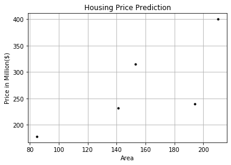

Linear Regression - Model

Model Regresi Linear akan memetakan satu atribut (*univariate*) atau beberapa atribut (*multivariate*) menjadi satu nilai output (target) berupa nilai real.

**Univariate Linear Regression** \begin{eqnarray} f:\Re^1 \rightarrow \Re \quad f(x;w)&=&w_0+w_1x \\ \end{eqnarray}

**Multivariate Linear Regression** \begin{eqnarray} f:\Re^d \rightarrow \Re \quad f(x;w)&=&w_0+w_1x_1+...+w_dx_d \\ \end{eqnarray}

Notasi :

- $f(x;w)$ atau $y$ : variabel output,

- $x$ : variabel input atau nilai atribute/fitur,

- $w$ : bobot atau *coefficients*; $w_0$ adalah nilai *intercept* atau *bias*

**Note**:

- Univariate Linear Regression untuk satu attribute/fitur

- Multivariate Linear Regression untuk beberapa attribute/fitur

*Training* - Buat Model Linear Regression

1. *Direct Equation* / *Matrix equation*

2. *Gradient Descent* (*stochastic/online* atau *batch/offline learning*)

Direct/Matrix Equation

Model *Univariate Linear Regression*

Linear Regression : $y=w_0+w_1x$  
Bias atau intercept, dan *coefficient* (*weights* : $w_0, w_1$), dihitung melalui persamaan berikut :

\begin{eqnarray} var(x)&=&\frac{\sum_{i=1}^{n}(x_i-\bar{x})^2}{n-1}\\ cov(x,y)&=&\frac{\sum_{i=1}^{n}(x_i-\bar{x})(y_i-\bar{y})}{n-1}\\ \end{eqnarray}

koefisien dan intercept dari model regressi linear adalah : \begin{eqnarray} w_1&=&\frac{cov(x,y)}{var(x)}\\ w_0&=&\bar{y}-w_1\bar{x} \end{eqnarray}

Kode *Training* Univariate Linear Regression

```
import simpleLinear
import numpy as np
```

```
X=np.array([[210],[141],[153],[85],[194]])
Y=np.array([[400],[232],[315],[178],[240]])
meanX=simpleLinear.meanData(X)
varX=simpleLinear.varianceData(X)
covData=simpleLinear.covarianceData(X,Y)
print(covData)
coefData=covData/varX
print('coef=',coefData)
intercept=simpleLinear.meanData(Y)-coefData*meanX
print('intercept=',intercept)
```

```
3209.5
coef= 1.3326828052983435
intercept= 64.30187269027942
```

```
dataX=np.linspace(80,220,50)
dataY=intercept+coefData*dataX
#plot Data training and testing
plt.title('Prediksi Harga Rumah')
plt.xlabel('Luas Rumah')
plt.ylabel('Harga juta')
plt.plot(X, Y, 'k.')
plt.plot(dataX, dataY, 'r-')
plt.grid(True)
plt.show()
```

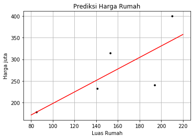

Kode *Testing* Univariate Linear Regression

Model yang dibentuk berdasarkan proses pelatihan : $y=64.3+1.33x$

```
dataTest=int(input('Luas rumah = '))
harga=intercept+coefData*dataTest
print('harga rumah =',harga)
```

```
Luas rumah = 100
harga rumah = 197.57015322011378
```

Exercise

Berikut adalah data *training* yang terdiri dari fitur $X$ dan target $Y$ .

[figure not shown]

Tugas :

1. *plot* data training

2. Hitung bobot (dan bias) secara manual, dan tulis model yang dihasilkan

3. Berdasarkan model yang dibuat, hitung output, jika input adalah 9 atau 10

4. Gambar grafik model linear regression, dan plot data training (*blue dots*) dan data testing (*red dot*)

Multivariate Linear Regression

Model Multivariate Linear Regression : $f(x;w)=w_0+w_1x_1+...+w_dx_d$ or $y=w_0+w_1x_1+...+w_dx_d$

Fungsi obyektif atau *loss function* diperlukan untuk perhitungan bobot atau *weight* :

Loss Function : \begin{eqnarray} J_n(w)=\frac{1}{n}\sum_{i=1}^{n}(y_i-f(x_i;w))^2 \end{eqnarray}

Bobot diperoleh dengan cara meminimalkan fungsi *loss* \begin{eqnarray} y= \begin{bmatrix} y_1 \\ ...\\ y_n \end{bmatrix} \quad X= \begin{bmatrix} 1 \quad x_1 \\ ... \quad...\\ 1 \quad x_n \end{bmatrix} \quad w= \begin{bmatrix} w_0 \\ ...\\ w_1 \end{bmatrix} \end{eqnarray}

\begin{eqnarray} \frac{1}{n}\sum_{i=1}^{n}(y_i-f(x;w))^2&=&\frac{1}{n} \Bigg[\begin{bmatrix} y_1\\ ...\\ y_n \end{bmatrix}-\begin{bmatrix} 1 \quad x_1\\ ...\quad ...\\ 1 \quad x_n \end{bmatrix} \begin{bmatrix} w_0\\ ...\\ w_1 \end{bmatrix} \Bigg]^2\\ &=&\frac{1}{n}[y-Xw]^2 \end{eqnarray}\begin{eqnarray} \frac{\partial}{\partial w}\frac{1}{n}[y-Xw]^2&=&\frac{2}{n}X^T(y-Xw)\\ &=&\frac{2}{n}(X^Ty-X^TXw)=0\\ w&=&(X^TX)^{-1}X^Ty \end{eqnarray}

Latihan

Berikut adalah data *training* yang terdiri dari fitur $X$ dan target $Y$ .

[figure not shown]

Tugas :

1. Buat model *linear regression* dengan menggunakan persamaan matriks, dan hitung weight secara manual (data yang digunakan adalah dua baris terakhir)

2. Buat model *linear regression* dengan kode program (menggunakan persamaan matriks)

3. Berapa output jika input adalah 6 atau 7

```
import numpy as np
import simpleLinear
X=np.array([[1],[2],[4],[3],[5]])
Y=np.array([[1],[3],[3],[2],[5]])
w=simpleLinear.linReg(X,Y)
print(w)
```

Latihan

Buat model linear regression (buat kode program sendiri) dengan menggunakan persamaan matriks :

1. gunakan dataset boston (scikit)

```
from sklearn import datasets
data=datasets.load_boston()
print(boston.data.shape)
```

```
features = data.data[0:100,0:2]
target = data.target[0:100]
w=simpleLinear.linReg(features,target)
print(w)
```

```
from sklearn.linear_model import LinearRegression

#create Model
model = LinearRegression()

# Learning
model.fit(features, target)
```

```
print(model.intercept_,model.coef_)
```

Gradient Descent Learning

Solusi optimal dicari dengan cara mencari nilai bobot secara iteratif, sedemikian hingga fungsi loss (misal : Mean Square Error) akan bernilai minimal.

[figure not shown]

*challenges* : Penentuan parameter *learning*  
Nilai paramater *learning* terlalu kecil:

[figure not shown]

Nilai paramater *learning* terlalu besar:

[figure not shown]

**Note :** Semua data fitur seharusnya punya skala yang sama --> **normalize data**

Training dengan : Stochastic dan Batch Gradient Descent

1. Stochastic Gradient Descent:  
   untuk semua data dalam data training : \begin{eqnarray} w_j=w_j-\eta(f(x^i)-y^i)x_j^i \end{eqnarray}

2. Batch Gradient Descent : \begin{eqnarray} w_j=w_j-\eta\frac{1}{n}\sum_{i=1}^{n}(f(x^i)-y^i)x_j^i \end{eqnarray}

$n$=jumlah data dalam data training  
$f(x_i)=$prediksi ke-$i$  
$y_i=$target output untuk data ke-$i$  
$d$= jumlah fitur  
$x_j=$fitur ke - $j$  
$x_0=1$ bias/intercept  
$w_j=$bobot untuk fitur ke - $j$

Latihan

Bangun model linear regression berdasarkan data berikut :

[figure not shown]

1. Hitung bobot dengan menggunakan SGD secara manual, sampai dengan lima iterasi

2. Buat Kode program secara manual

3. Buat kode program dengan menggunakan scikit

```
import numpy as np
import matplotlib.pyplot as plt
X=np.array([[1],[2],[4],[3],[5]])
Y=np.array([[1],[3],[3],[2],[5]])

w=simpleLinear.stochasticGD(X,Y,10,0.02)
print(w)
print(w.shape[0])
```

```
# draw the regression
import matplotlib.pyplot as plt

plt.title('Prediksi dummy Data')
plt.xlabel('X')
plt.ylabel('Y')
plt.plot(X, Y, 'k.')
plt.grid(True)
data=np.linspace(1,7,10)
for i in range(w.shape[0]):
    y=w[i,0]+w[i,1]*data
    #print(y)
    plt.plot(data,y,'r-')
y=w[w.shape[0]-1,0]+w[w.shape[0]-1,1]*data
plt.plot(data,y,'b-')
#plt.show()
```

Linear Regression dengan scikit

**Training/Learning**

- *load training dataset (features and target)*

- buat Model

- lakukan proses training atau learning

**Testing**

- Load Model

- test model dengan data test / *Generalize*

```
import numpy as np
from sklearn.linear_model import LinearRegression

X=np.array([[210],[141],[153],[85],[194]])
Y=np.array([[400],[232],[315],[178],[240]])
print(X.shape, Y.shape)

#create Model
model = LinearRegression()

# Learning
model.fit(X, Y)
```

```
(5, 1) (5, 1)
```

```
LinearRegression(copy_X=True, fit_intercept=True, n_jobs=None, normalize=False)
```

```
# Testing
print('coef=',model.coef_)
print('intercept=',model.intercept_)

newArea=np.array([[125]])
predPrice=model.predict(newArea)
print(predPrice)
```

```
coef= [[1.33268281]]
intercept= [64.30187269]
[[230.88722335]]
```

```
import matplotlib.pyplot as plt
%matplotlib inline

plt.title('Housing Price Prediction')
plt.xlabel('Area')
plt.ylabel('Price in Million($)')
plt.plot(X, Y, 'k.')
plt.plot(newArea,predPrice,'r.')
plt.grid(True)
plt.show()
```

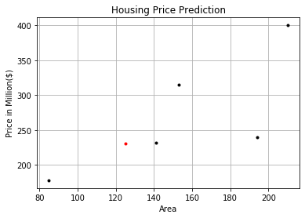

Akurasi

Perhitungan kinerja untuk mengukur seberapa akurat model yang dihasilkan untuk proses generalisasi. *R-Square* untuk mengukur model linear regressi.  
Nilai *r-squared* antara 0 s.d 1, nilai 1 berarti output dapat diprediksi secara benar tanpa ada error.

\begin{eqnarray} SS_{tot}&=&\sum_{i=1}^{n}(y_i-\bar{y})^2\\ SS_{res}&=&\sum_{i=1}^{n}(y_i-f(x_i))^2\\ R^2&=&1-\frac{SS_{res}}{SS_{tot}} \end{eqnarray}

where  
$y_i=$target data ke -$i$  
$\bar{y}=$mean target  
$n=$jumlah data  
$x_i=$data ke -$i$  
$f(x_i)=$prediksi untuk data ke - $i$

```
# Accuracy using scikit

from sklearn.linear_model import LinearRegression
model = LinearRegression()
X=[[1],[2],[4],[3],[5]]
Y=[[1],[3],[3],[2],[5]]
model.fit(X, Y)
print(model.score(X,Y))

#model.predict(data)
```

Polynomial Regression

Model Linear Regression dibangun berdasarkan asumsi bahwa relasi antara input dan output adalah linear, : $y=w_0+w_1x$.  
Terkadang data tidak hanya linear, tapi lebih kompleks : Polynomial Regression

**Note :** Linear Regression, Univariate Linear Regression, Multivariate Linear Regression, Polynomial Regression

Salah satu model Polynomial Regression adalah **Quadratic Regression**, $y=w_0+w_1x+w_2x^2$ (*univariate polynomial regression*)

Proses training dapat dilakukan dengan Matrix Equation atau *Gradient Descent*/*incremental* learning.

[figure not shown]

$X=[[1],[2],[4],[3],[5]]$ dan $Y=[[1],[3],[3],[2],[5]]$

Karena model yang dibangun adalah quadratic regression, maka input $x$ menjadi : $[[1,1,1],[1,2,4],[1,4,16],[1,3,9],[1,5,25]]$

```
# Polynomial regression untuk univariate #
from numpy.linalg import inv
from numpy import dot, transpose
import matplotlib.pyplot as plt
import numpy as np

X=[[1,1,1],[1,2,4],[1,4,16],[1,3,9],[1,5,25]]
Y=[[1],[3],[3],[2],[5]]
w=(dot(inv(dot(transpose(X), X)), dot(transpose(X), Y)))
print(w)

X=[[1],[2],[4],[3],[5]]
Y=[[1],[3],[3],[2],[5]]

plt.title('Prediksi dummy Data')
plt.xlabel('X')
plt.ylabel('Y')
plt.plot(X, Y, 'k.')
plt.grid(True)
dataX=np.linspace(1,7,100)
dataY=w[0,0]+w[1,0]*dataX+w[2,0]*dataX**2
dataYLinear=0.4+0.8*dataX #linear Regression
plt.plot(dataX, dataY, 'r-')
plt.plot(dataX, dataYLinear, 'b-')

plt.show()
```

```
# Scikit

from sklearn.linear_model import LinearRegression
from sklearn.preprocessing import PolynomialFeatures

#Linear Regresion
X=[[1],[2],[4],[3],[5]]
Y=[[1],[3],[3],[2],[5]]
model_linear = LinearRegression()
model_linear.fit(X, Y)
print('Linear Score=',model_linear.score(X,Y))

#Polinomial Regresion
trans=PolynomialFeatures(degree=2)
x_quad=trans.fit_transform(X)
print(x_quad)
model_quad = LinearRegression()
model_quad.fit(x_quad,Y)
print(model_quad.coef_)
print(model_quad.intercept_)
print('Polynomial Score=',model_quad.score(x_quad,Y))
```

Classification and Regression Trees - CART

CART dapat digunakan untuk permasalahan klasifikasi ataupun regresi berdasarkan beberapa level *decision tree*.  
Decision Tree :

- Node : fitur / atribut

- link/branch/edge : *path*

- leaf : output

[figure not shown]

Kelebihan :

1. Proses pengambilan keputusan sama dengan cara berfikir logis

2. Decision Tree dapat divisualisasikan (bukan *a black box*)

Algoritma

CART adalah *binary tree* yang dibangun berdasarkan nilai **Gini Impurity** (Gini Index). Tahapan pembentukan binary tree :

1. Siapkan dataset (fitur dan targetnya)

2. Tentukan *best split* berdasarkan nilai Gini Impurity dan Gini Split

3. Bagi data menjadi dua bagian (left dan right)

4. Ulangi langkah 2-3 sampai *stopping criteria* terpenuhi (gini impurity = 0, atau kedalaman binary tree)

Gini Impurity

\begin{eqnarray} Gini_t=1-\sum_{k=1}^n(P_{t,k})^2 \end{eqnarray}

dimana:

- $G_i$ : Gini Impurity dari sebuah node $t$,

- $n$ : jumlah kelas,

- $P_{t,k}$ : rasio kelas-$k$ dari seluruh dataset pada suatu node -$t$

Gini Split

\begin{eqnarray} Gini(s,t)=Gini(t)-P_{L}Gini(t_{L})-P_{R}Gini(t_{R})\\ \end{eqnarray}

dimana:

- $Gini(s,t)$ = Gini Split dari split-$s$ dan node-$t$

- $Gini(t)$ = Gini impurity atau Gini Index dari sebuah node-$t$

- $Gini(t_{L})$ = Gini impurity atau Gini Index dari *left child node* setelah proses spliting pada split $s$

- $P_{L}$ = rasio sample data (pada *left node*) atau rasio jumlah data pada left node berdasarkan seluruh data

- $Gini(t_{R})$ = Gini impurity atau Gini Index dari *right child node* setelah proses spliting pada split $s$

- $P_{R}$=rasio sample data (pada *right node*) atau rasio jumlah data pada left node berdasarkan seluruh data

Cut Value

Data pelatihan dibagi menjadi dua grup (*left* dan *right*) berdasarkan *best split* dan *cut value*. Nilai *cut value* ini didapatkan dengan :

1. Uruthkan data berdasarkan data fitur yang berbeda

2. Cari median tiap dua data yang berurutan

Data

- Iris,

- feature : sepal length (1 feature)

- number of data : 6 (@2), yaitu :

| Fitur | Kelas |
| --- | --- |
| 5.1 | 0 |
| 4.9 | 0 |
| 7 | 1 |
| 6.4 | 1 |
| 6.3 | 2 |
| 5.8 | 2 |

Training - Pembentukan binary tree

1. Hitung cut value

| Fitur | Kelas | cut value |
| --- | --- | --- |
| 4.9 | 0 |  |
| 5.1 | 0 | 5 |
| 5.8 | 2 | 5.45 |
| 6.3 | 2 | 6.05 |
| 6.4 | 1 | 6.35 |
| 7 | 1 | 6.7 |

2. Gini Index/Impurity untuk masing-masing grup (*left* atau *right*)

Untuk pertama kali, hitung gini index/impurity dataset :

| kelas | Jumlah Data | $P_{t,k}$ |
| --- | --- | --- |
| 0 | 2 | $2/6$ |
| 1 | 2 | $2/6$ |
| 2 | 2 | $2/6$ |
| **Total** | **6** |  |

**Gini Impurity** \begin{eqnarray} Gini_t&=&1-\sum_{k=1}^n(P_{t,k})^2 \\ Gini_1&=&1-\sum_{k=0}^2(P_{1,k})^2 \\ &=&1-(P_{1,0}^2+P_{1,1}^2+P_{1,2}^2)\\ &=&1-(0.333^2+0.333^2+0.333^2)\\ &=&0.6667 \end{eqnarray}

3. Tentukan Best Split

Hitung Gini split masing-masing *cut value*, cut value akan digunakan sebagai node, jika mempunyai nilai gini split yang paling besar.

split = 5

[output not shown]

Grup - Left

| kelas | Jumlah Data | $P_{1,k}$ |
| --- | --- | --- |
| 0 | 1 | $1/1$ |
| 1 | 0 | $0/1$ |
| 2 | 0 | $0/1$ |
| **Total** | **1** |  |

Grup - Right

| kelas | Jumlah Data | $P_{1,k}$ |
| --- | --- | --- |
| 0 | 1 | $1/5$ |
| 1 | 2 | $2/5$ |
| 2 | 2 | $2/5$ |
| **Total** | **5** |  |

Gini Split

\begin{eqnarray} Gini(s,t)&=&Gini(t)-P_{L}Gini(t_{L})-P_{R}Gini(t_{R})\\ Gini(5,1)&=&Gini_1-P_{L}Gini_{1L}-P_{R}Gini_{1R}\\ &=&0.667-\frac{1}{6}*0-\frac{5}{6}*0.64\\ &=&0.133 \end{eqnarray}

Lakukan tiga langkah diatas sampai menemukan nilai gini split terbesar.

Untuk node pertama, dengan enam data iris tersebut, cut value yang memiliki nilai gini split terbesar adalah, $cut value = 5.45$

CART with scikit

```
from sklearn import datasets
from sklearn. tree import DecisionTreeClassifier
import numpy as np
```

```
dataTraining=datasets.load_iris()
temp1=dataTraining.data[0:2,:]
temp2=dataTraining.data[50:52,:]
temp3=dataTraining.data[100:102,:]
feature=np.concatenate((temp1, temp2,temp3), axis=0)
#print('feature=',feature)
target=np.array([0,0,1,1,2,2])
#target=dataTraining.target
feat=feature[:,0]
print(feat)
print(target)
```

```
[5.1 4.9 7.  6.4 6.3 5.8]
[0 0 1 1 2 2]
```

```
a=np.reshape(feat, (-1, 1))
```

Training

```
treeClf=DecisionTreeClassifier(max_depth=2)
treeClf.fit(a,target)
```

```
DecisionTreeClassifier(class_weight=None, criterion='gini', max_depth=2,
                       max_features=None, max_leaf_nodes=None,
                       min_impurity_decrease=0.0, min_impurity_split=None,
                       min_samples_leaf=1, min_samples_split=2,
                       min_weight_fraction_leaf=0.0, presort=False,
                       random_state=None, splitter='best')
```

CART visualization

```
from sklearn. tree import export_graphviz
export_graphviz(
treeClf,
out_file="iris_tree. dot",
feature_names=dataTraining.feature_names[0:1] ,
class_names=dataTraining.target_names,
rounded=True,
filled=True
)
```

open http://webgraphviz.com/ , and copy file tree

[figure not shown]

CART for the dataset

[figure not shown]

Testing

```
data=np.array([[5.4,3.7, 1.5, 0.2]])
print(data)
output=treeClf.predict(dataTraining.data)
print(output)
```

CART with your own Code

```
import cart
import numpy as np

# Main
bestCut=cart.calculateCutVal(feat)
print('best cut=',bestCut)
#Gini awal, dengan anggapan split adalah 1000, oleh karena itu data berada di leftgrup
l,r=cart.splitData(feat,target,1000)
initGini=cart.calculateGiniImpurity(l)
giniSplit=np.zeros_like(bestCut)
for i in range(len(bestCut)):
    giniSplit[i]=cart.calculateGiniSplit(initGini,bestCut[i],feat,target)
print('gini split=',giniSplit)
bestSplit=bestCut[np.argmax(giniSplit)]
print(bestSplit)
```

```
best cut= [5.   5.45 6.05 6.35 6.7 ]
gini split= [0.13333333 0.33333333 0.22222222 0.33333333 0.13333333]
5.449999999999999
```

```
# depth =2
l,r=cart.splitData(feat,target,bestSplit)
print(l,r)
giniL=cart.calculateGiniImpurity(l)
giniR=cart.calculateGiniImpurity(r)
print(giniL,giniR)
```

```
[2. 0. 0.] [0. 2. 2.]
0.0 0.5
```

Artificial Neural Networks / Jaringan Syaraf Tiruan

Jaringan Syaraf

[figure not shown]

Kelebihan :

1. Pembelajaran

2. Beradaptasi

3. Generalisasi

4. *Pararelism*

[figure not shown]

Implementasi

Pengenalan Suara

[figure not shown]

Identifikasi Atribut

[figure not shown]

Neuron

[figure not shown]

Abstraksi neuron - NN

[figure not shown]

Neuron memetakan input dengan dimensi *d* menjadi [0,1] or [-1,1] : \begin{equation*} f:\mathbb{R}^d \rightarrow [0,1] \end{equation*} atau \begin{equation*} f:\mathbb{R}^d \rightarrow [-1,1] \end{equation*}

Pemrosesan input :

1. Hitung net input \begin{equation*} net=x_1w_1+x_2w_2+...+x_dw_d\\ net=\sum_{i=1}^{d}x_iw_i \end{equation*} dimana : \begin{equation*} x_{1..d} = \textrm{sinyal input/fitur dengan jumlah dimensi $d$} \\ w_{1..d} = \textrm{bobot setiap sinyal input} \end{equation*}

2. Hitung nilai aktivasi \begin{equation*} y=f(net)\\ y=f\big(\sum_{i=1}^{d}x_iw_i\big) \end{equation*} dimana $f(net)$ adalah fungsi aktivasi

Activation Function

1. Fungsi *Linear* \begin{eqnarray} f(netInput)=netInput \end{eqnarray}

[figure not shown]

2. Fungsi *Stepwise* \begin{eqnarray} f(netInput)= \begin{cases} \gamma_1, & \text{if}\ netinput \geq \theta \\ \gamma_2, & \text{if}\ netinput \lt \theta \end{cases} \end{eqnarray}

[figure not shown]

3. Fungsi *Sigmoid* \begin{eqnarray} f(netInput)=\frac{1}{1+e^{-\lambda(netInput-\theta)}} \end{eqnarray}

[figure not shown]

Perceptron

Satu *layer*, yaitu *output layer* (terdiri dari sejumlah neuron)

[figure not shown]

Agar perceptron dapat men-generalisasi sinyal input, maka diperlukan proses pelatihan/pembelajaran:

1. Model (arsitektur jaringan syaraf dan bobotnya) dapat dibentuk setelah proses pembelajaran/pelatihan.

2. bobot di*update* agar mendapatkan error minimal

**Algoritma Pembelajaran Perceptron**

1. Inisialisasi Bobot

2. Hitung net input \begin{equation*} y=f\big(\sum_{i=1}^{d}x_iw_i\big) \end{equation*}

3. Hitung output atau nilai aktivasi dari neuron output berdasarkan fungsi aktivasi, misal: fungsi *stepwise*

4. update bobot : \begin{equation*} w_i(t+1)=w_i \textrm{ ; if output==targetOutput} \\ w_i(t+1)=w_i+x_i(t) \textrm{ ; if output < targetOutput} \\ w_i(t+1)=w_i-x_i(t) \textrm{ ; if output > targetOutput} \end{equation*}

5. Lakukan langkah 2-4 sampai jumlah epoch yang telah ditentukan atau error minimum telah dicapai

Latihan

Buat sebuah model perceptron dengan menggunakan data logical AND, dan asumsi bobot awal adalah $w_1=0.1$ and $w_2=0.2$, jumlah epoch = 3

| X1 | X2 | Y |
| --- | --- | --- |
| 1 | 1 | 1 |
| 1 | 0 | 0 |
| 0 | 1 | 0 |
| 0 | 0 | 0 |

Learning on Perceptron

- **Algoritma-1**

  1. Inisialisasi bobot dan bias ($w_0$)

  2. hitung net input \begin{equation*} y=f\big(\sum_{i=0}^{d}x_iw_i\big) \end{equation*}

  3. hitung output ata nilai aktivasi neuron output berdasarkan fungsi aktivasi, misal : fungsi *stepwise*

  4. update bobot : \begin{equation*} w_i(t+1)=w_i \textrm{ ; if output==targetOutput} \\ w_i(t+1)=w_i+x_i(t) \textrm{ ; jika output < targetOutput} \\ w_i(t+1)=w_i-x_i(t) \textrm{ ; jika output > targetOutput} \end{equation*}

  5. Lakukan langkah 2-4 sampai jumlah epoch tertentu atau error minimum telah tercapai

- **Algoritma-2**

  1. update bobot : \begin{equation*} w_i(t+1)=w_i \textrm{ ; if output==targetOutput} \\ w_i(t+1)=w_i+\eta x_i(t) \textrm{ ; jika output < targetOutput} \\ w_i(t+1)=w_i-\eta x_i(t) \textrm{ ; jika output > targetOutput} \end{equation*}

- **Algoritma-3**

  1. update bobot : \begin{equation*} \Delta=d(t)-y(t)\\ \textrm{ ; d(t) adalah data target dan y(t) adalah output sebenarnya } \\ w_i(t+1)=w_i(t)+\eta \Delta x_i(t) \end{equation*}

Perceptron dengan scikit

```
import numpy as np
data=np.array([[1,1],[1,0],[0,1],[0,0]]) # data
targetAnd=np.array([1,0,0,0])
```

```
from sklearn.linear_model import Perceptron
```

```
clf = Perceptron(tol=1e-3, random_state=0)
clf.fit(data, targetAnd)
```

```
Perceptron(alpha=0.0001, class_weight=None, early_stopping=False, eta0=1.0,
           fit_intercept=True, max_iter=1000, n_iter_no_change=5, n_jobs=None,
           penalty=None, random_state=0, shuffle=True, tol=0.001,
           validation_fraction=0.1, verbose=0, warm_start=False)
```

```
print(clf.coef_)
print(clf.intercept_)
```

```
[[2. 2.]]
[-2.]
```

```
#testing
clf.predict(data)
```

```
array([1, 0, 0, 0])
```

Code : perceptron

```
import numpy as np
import matplotlib.pyplot as matPlot
#inisialisasi data
data=np.array([[1,1,1],[1,1,0],[1,0,1],[1,0,0]]) # bias dan data
targetAnd=np.array([1,0,0,0])
targetOr=np.array([1,1,1,0])
targetXor=np.array([0,1,1,0])
targetAndNOT=np.array([0,1,0,0])
targetnotPOrQ=np.array([1,0,1,1])
targetPOrnotQ=np.array([1,1,0,1])
```

```
import perceptron
```

```
perceptron.plotting(data,targetAnd)
```

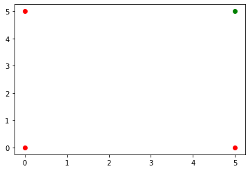

```
weight=perceptron.perceptronLearning(data,targetAnd)
```

[output not shown]

[output cut: 197 more lines]

[output not shown]

```
print(weight[:,40])
```

```
[-2.7  1.2  2.4]
```

```
#testing

for i in range(4):
    nilai=perceptron.activationValue(data[i,:],weight[:,40])
    print(nilai)
```

```
1
0
0
0
```

```
#visualisation
perceptron.detFunction(weight,'b')
```

```
41
```

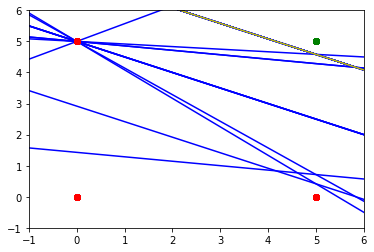

Exercise

build a model using perceptron of logical data XOR

| X1 | X2 | Y |
| --- | --- | --- |
| 1 | 1 | 0 |
| 1 | 0 | 1 |
| 0 | 1 | 1 |
| 0 | 0 | 0 |